# Series 7 – Fitting a Logistic Regression in Bayes

Biostatistics

Tutorial

R

Bayesian Methods

JAGS/Stan

How to fit a Logistic Regression using Bayesian Methods  
The advantage of using Bayes to overcome the Separation in Logistic Regression

Hai Nguyen  
March 20, 2022

# Logistic regression

## Prediction of gender by hight and weight. Probability close to 0.5 (balanced data)

```r
mydf <- read.csv(file = 'data/HtWtData300.csv')
head(mydf)
```

```
  male height weight
1    0   64.0  136.4
2    0   62.3  215.1
3    1   67.9  173.6
4    0   64.2  117.3
5    0   64.8  123.3
6    0   57.5   96.5
```

Probability close to 0.5

```r
table(mydf$male)
```

```
  0   1
152 148
```

```r
prop.table(table(mydf$male))
```

```
        0         1
0.5066667 0.4933333
```

Firstly, we try to fit with `glm`

```r
fmod1 <- glm(male ~ height + weight,
             family = "binomial", data = mydf)
summary(fmod1)
```

```
Call:
glm(formula = male ~ height + weight, family = "binomial", data = mydf)

Deviance Residuals:
    Min       1Q   Median       3Q      Max
-2.7751  -0.4674  -0.0165   0.3655   3.1906

Coefficients:
              Estimate Std. Error z value Pr(>|z|)
(Intercept) -59.994880   7.136907  -8.406  < 2e-16 ***
height        0.890858   0.108873   8.183 2.78e-16 ***
weight        0.005320   0.005225   1.018    0.309
---
Signif. codes:  0 '***' 0.001 '**' 0.01 '*' 0.05 '.' 0.1 ' ' 1

(Dispersion parameter for binomial family taken to be 1)

    Null deviance: 415.83  on 299  degrees of freedom
Residual deviance: 189.49  on 297  degrees of freedom
AIC: 195.49

Number of Fisher Scoring iterations: 6
```

$\Rightarrow$ We will see the estimates as same as the Bayesian method.

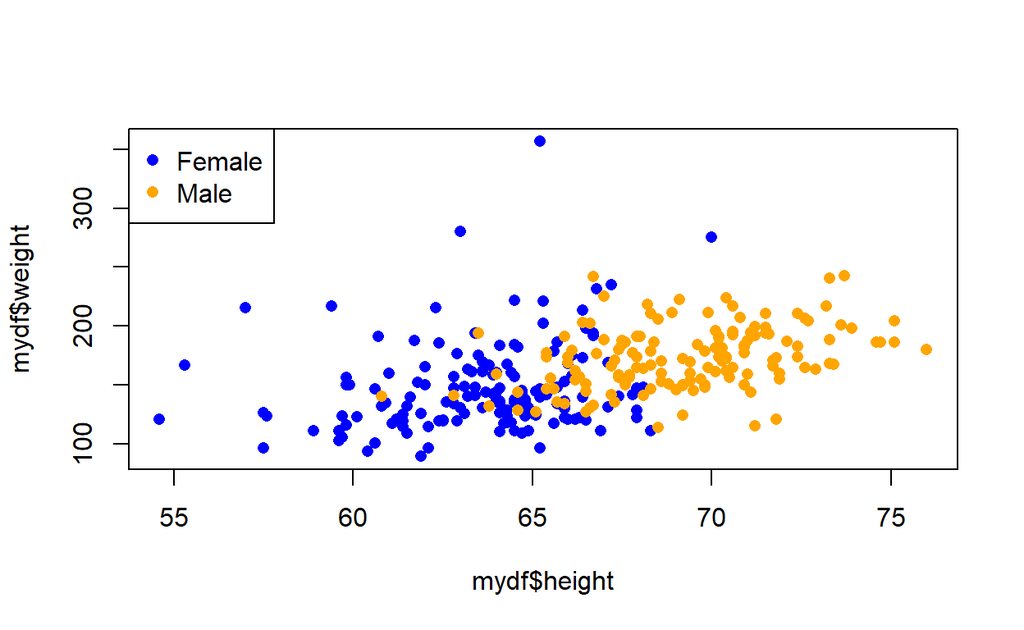

```r
plot(mydf$height,
     mydf$weight,pch=16, col="blue")
points(mydf$height[mydf$male==1],
       mydf$weight[mydf$male==1],
       col="orange", pch=16)
legend("topleft", legend=c("Female","Male"),
       col=c("blue","orange"), pch=16)
```

Model for Dichotomous y with multiple metric predictors set up in `Stan`

But firstly, we look at the simplified `modelString` of Stan:

```r
# Not eval
modelString <- "
  data{
    int<lower=0> N;
    real xc[N];
    int xb[N];
    int<lower=0,upper=1> y[N]; //Binary outcome
  }
  parameters{
    real b0;
    real b1;
    real b2;
  }
  model{
    b0 ~ normal(0,1);
    b1 ~ normal(0,1);
    b2 ~ normal(0,1);
    y  ~ bernoulli_logit(b0 + b1*xc + b2*xb);
  }
"
```

Then move on the destination one:

```r
modelString <- "
  data {
    int<lower=1> Ntotal; // num of observations
    int<lower=1> Nx;     // num of predictors
    int<lower=0, upper=1> y[Ntotal];
    matrix[Ntotal, Nx] x;
  }

  transformed data {
    vector[Nx] meanX;
    vector[Nx] sdX;
    matrix[Ntotal, Nx] zx; // normalized

    for ( j in 1:Nx ) {
      meanX[j] = mean(x[,j]);
      sdX[j] = sd(x[,j]);
        for (i in 1:Ntotal) {
          zx[i,j] = (x[i,j] - meanX[j]) / sdX[j];
        }
      }
  }

  parameters {
    real zbeta0;
    vector[Nx] zbeta;
  }

  transformed parameters{
    vector[Ntotal] mu;
    mu = zbeta0 + zx * zbeta;  // matrix product
  }

  model {
    zbeta0 ~ normal(0, 2);
    zbeta  ~ normal(0, 2);
    y ~ bernoulli_logit(mu);
  }

  generated quantities {
    // Transform to original scale:
    real beta0;
    vector[Nx] beta;
    // .* and ./ are element-wise product and division
    beta0 = zbeta0 - sum(zbeta .* meanX ./ sdX);
    beta = zbeta ./ sdX;
  }
"
```

```r
stanDsoLogistic <- stan_model(model_code=modelString)
# save(stanDsoLogistic, file = "data/stanLogisticDso.Rdata")
```

```r
load(file = "data/stanLogisticDso.Rdata")
```

Fit model

```r
heightWeightDataList <- list(Ntotal = nrow(mydf),
                             y = mydf$male,
                             x = cbind(mydf$height, mydf$weight),
                             Nx = 2)
```

```r
fit <- sampling(stanDsoLogistic,
                data = heightWeightDataList,
                pars = c('beta0', 'beta'),
                iter = 5000, chains = 2, cores = 2
)
```

Analyze fitted model using shinystan

```r
launch_shinystan(fit)
```

Analyze parameters.

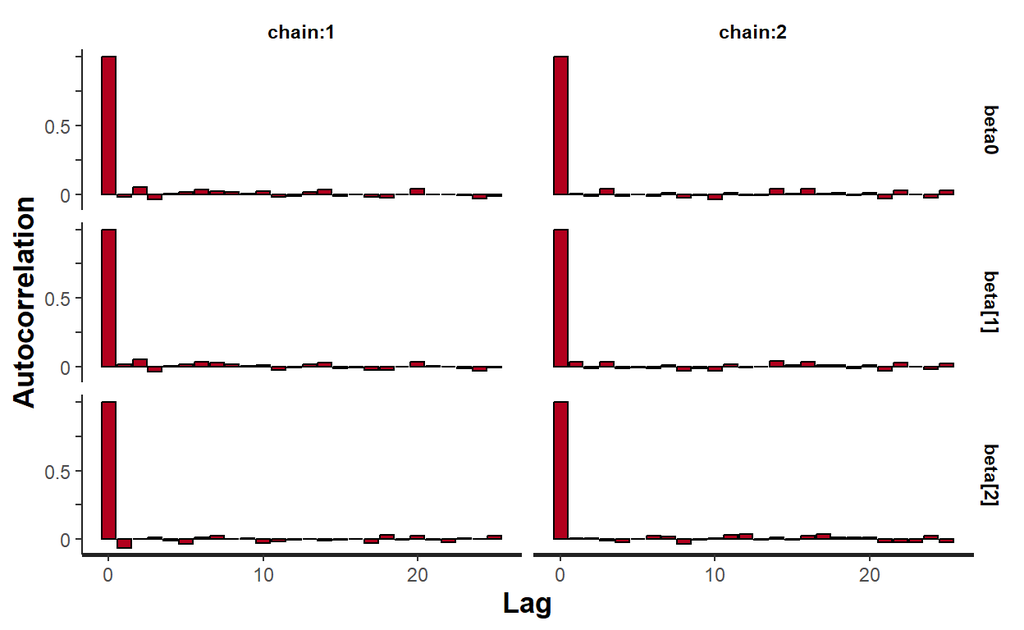

```r
stan_ac(fit, separate_chains = T)
```

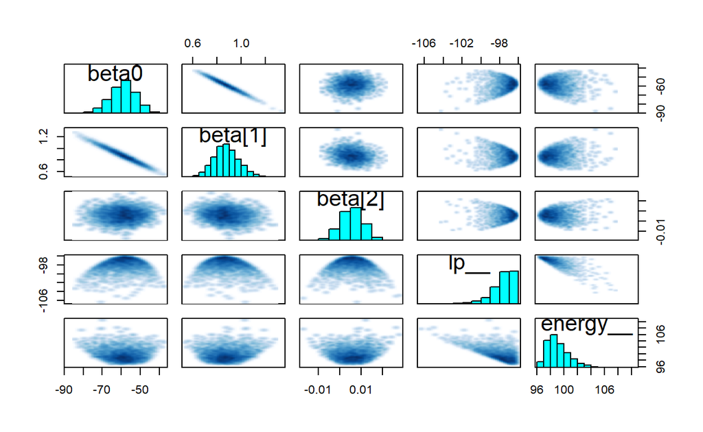

```r
pairs(fit)
```

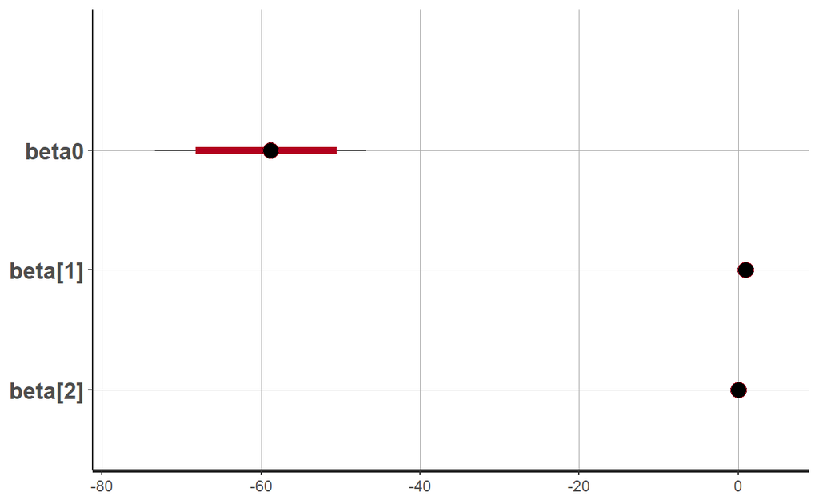

```r
plot(fit)
```

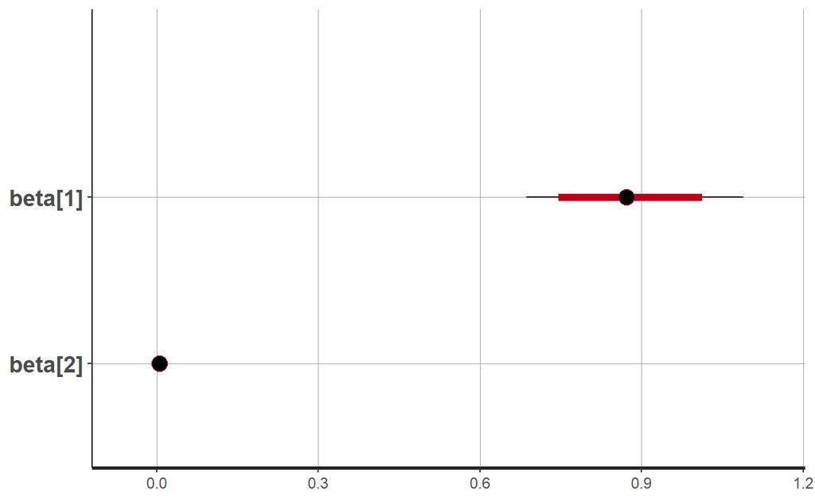

```r
plot(fit,pars=c("beta"))
```

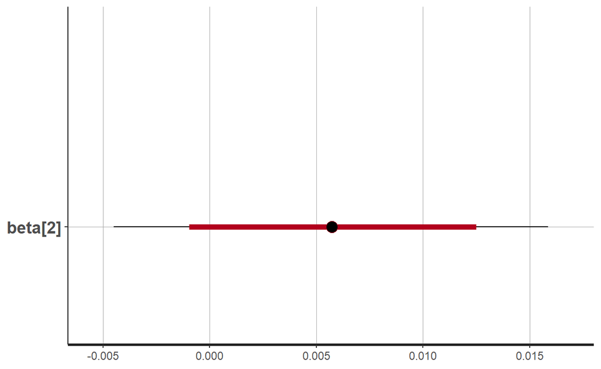

```r
plot(fit,pars=c("beta[2]"))
```

```r
summary(fit)$summary[,c(1,4,8)]
```

```
                 mean          2.5%        97.5%
beta0   -59.074628416 -7.332501e+01 -46.74736282
beta[1]   0.876102572  6.866473e-01   1.08922356
beta[2]   0.005720759 -4.493517e-03   0.01585729
lp__    -97.682840004 -1.008467e+02 -96.28774967
```

Parameter $\beta_2$ is not significant with 95% HDI.

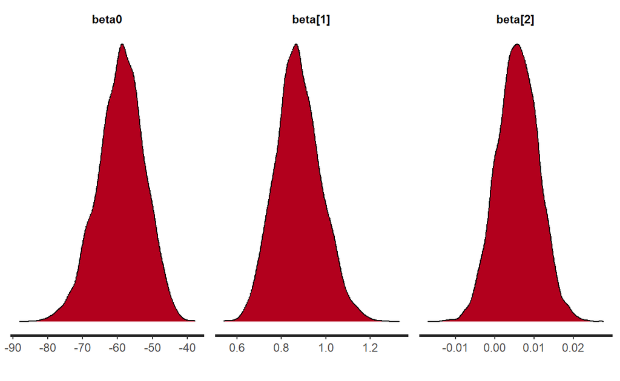

```r
stan_dens(fit)
```

```r
estimBetas<-summary(fit)$summary[1:3,1]
```

Plot the data with separating hyperplane.

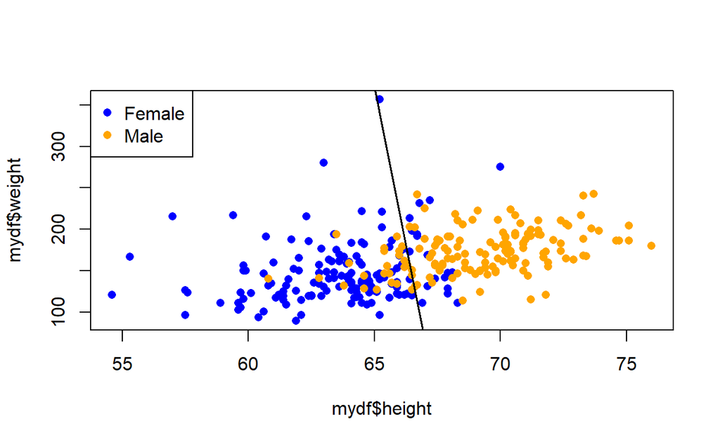

```r
plot(mydf$height, mydf$weight, pch=16, col="blue")
points(mydf$height[mydf$male==1], mydf$weight[mydf$male==1], col = "orange", pch = 16)
lines(mydf$height, -(estimBetas[1]+estimBetas[2]*mydf$height)/estimBetas[3])
legend("topleft", legend = c("Female","Male"), col = c("blue","orange"), pch=16)
```

## Prediction of gender by hight and weight. Probability close to extreme (imbalanced sample)

Now try to remove almost all males from the sample to see what may happen when there are few 1’s observed.

In the original sample the proportion of males is:

```r
mean(mydf$male)
```

```
[1] 0.4933333
```

Sample with females is

```r
females <- mydf[mydf$male == 0,]
```

Select first 15 males.

```r
males <- mydf[mydf$male == 1,][1:15,] # just 15 males (originally was ~150)
mydf_sparse <- rbind(males,females)
rownames(mydf_sparse) <- NULL
head(mydf_sparse, 20)
```

```
   male height weight
1     1   67.9  173.6
2     1   70.2  191.1
3     1   71.1  193.9
4     1   66.5  127.1
5     1   75.1  204.4
6     1   64.6  143.4
7     1   69.2  124.4
8     1   68.1  140.9
9     1   72.6  164.7
10    1   71.5  193.6
11    1   76.0  180.0
12    1   69.7  155.0
13    1   73.3  188.2
14    1   68.3  178.6
15    1   70.8  207.3
16    0   64.0  136.4
17    0   62.3  215.1
18    0   64.2  117.3
19    0   64.8  123.3
20    0   57.5   96.5
```

Fit sparse model

```r
fmod2 <- glm(male ~ height + weight, family = "binomial", data = mydf_sparse)
summary(fmod2)
```

```
Call:
glm(formula = male ~ height + weight, family = "binomial", data = mydf_sparse)

Deviance Residuals:
     Min        1Q    Median        3Q       Max
-1.28353  -0.17117  -0.06829  -0.01696   3.15051

Coefficients:
             Estimate Std. Error z value Pr(>|z|)
(Intercept) -84.24302   20.03395  -4.205 2.61e-05 ***
height        1.25377    0.30728   4.080 4.50e-05 ***
weight       -0.01190    0.01248  -0.953     0.34
---
Signif. codes:  0 '***' 0.001 '**' 0.01 '*' 0.05 '.' 0.1 ' ' 1

(Dispersion parameter for binomial family taken to be 1)

    Null deviance: 100.909  on 166  degrees of freedom
Residual deviance:  35.582  on 164  degrees of freedom
AIC: 41.582

Number of Fisher Scoring iterations: 8
```

```r
heightWeightSparseDataList<-list(Ntotal=nrow(mydf_sparse),
                                 y=mydf_sparse$male,
                                 x=cbind(mydf_sparse$height, mydf_sparse$weight),
                                 Nx=2)
```

```r
fit_sparse <- sampling(stanDsoLogistic,
                       data=heightWeightSparseDataList,
                       pars=c('beta0', 'beta'),
                       iter=5000, chains = 2, cores = 2
)
```

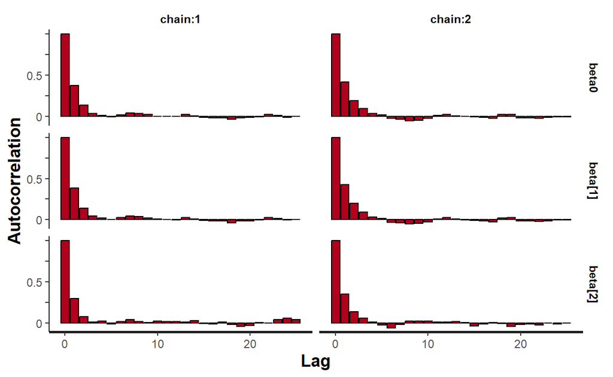

```r
stan_ac(fit_sparse, separate_chains = T)
```

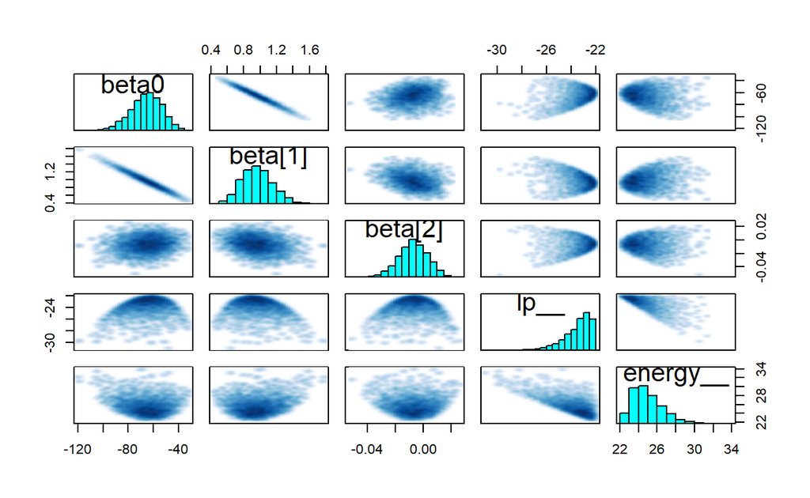

```r
pairs(fit_sparse)
```

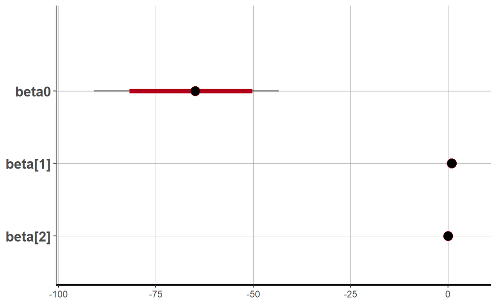

```r
plot(fit_sparse)
```

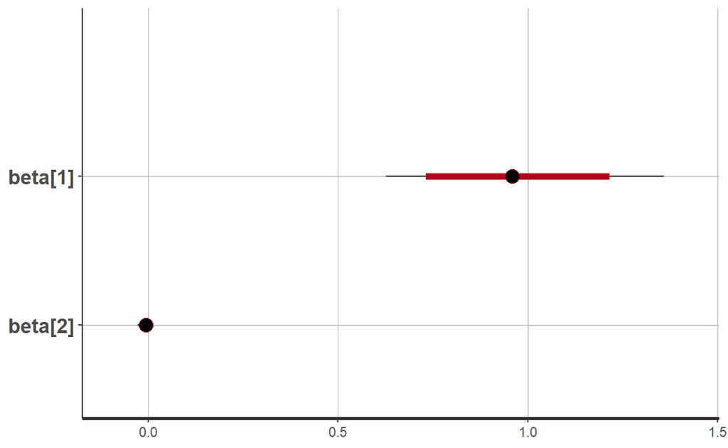

```r
plot(fit_sparse,pars=c("beta"))
```

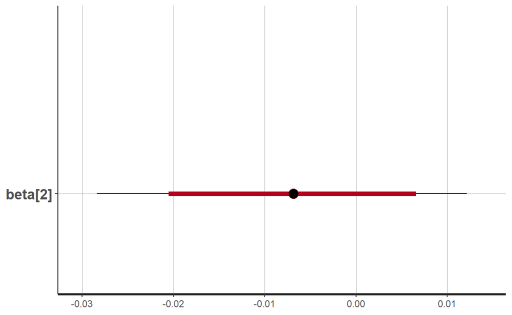

```r
plot(fit_sparse,pars=c("beta[2]"))
```

Compare summary of the two studies

```r
rbind(beta0reg=summary(fit)$summary[1,c(1,3)],
      beta0glm=c(summary(fmod1)$coefficients[1,1],summary(fmod1)$coefficients[1,2]*sqrt(dim(mydf)[1])),
      beta0sparce=summary(fit_sparse)$summary[1,c(1,3)],
      beta0sparceglm=c(summary(fmod2)$coefficients[1,1],summary(fmod2)$coefficients[1,2]*sqrt(dim(mydf_sparse)[1])))
```

```
                    mean         sd
beta0reg       -59.07463   6.749991
beta0glm       -59.99488 123.614858
beta0sparce    -65.48010  12.250007
beta0sparceglm -84.24302 258.895713
```

```r
rbind(beta1reg=summary(fit)$summary[2,c(1,3)],
      beta1glm=c(summary(fmod1)$coefficients[2,1],summary(fmod1)$coefficients[2,2]*sqrt(dim(mydf)[1])),
      beta1sparce=summary(fit_sparse)$summary[2,c(1,3)],
      beta1sparceglm=c(summary(fmod2)$coefficients[2,1],summary(fmod2)$coefficients[2,2]*sqrt(dim(mydf_sparse)[1])))
```

```
                    mean        sd
beta1reg       0.8761026 0.1030361
beta1glm       0.8908578 1.8857272
beta1sparce    0.9664459 0.1882613
beta1sparceglm 1.2537728 3.9708903
```

```r
rbind(beta2reg=summary(fit)$summary[3,c(1,3)],
      beta2glm=c(summary(fmod1)$coefficients[3,1],summary(fmod1)$coefficients[3,2]*sqrt(dim(mydf)[1])),
      beta2sparce=summary(fit_sparse)$summary[3,c(1,3)],
      beta2sparceglm=c(summary(fmod2)$coefficients[3,1],summary(fmod2)$coefficients[3,2]*sqrt(dim(mydf_sparse)[1])))
```

```
                       mean          sd
beta2reg        0.005720759 0.005286843
beta2glm        0.005319759 0.090499569
beta2sparce    -0.007041950 0.010449550
beta2sparceglm -0.011900490 0.161304086
```

```r
rbind(beta0reg=summary(fit)$summary[1,c(4,8)],
      beta0sparce=summary(fit_sparse)$summary[1,c(4,8)])
```

```
                 2.5%     97.5%
beta0reg    -73.32501 -46.74736
beta0sparce -90.86386 -43.48094
```

```r
rbind(beta1reg=summary(fit)$summary[2,c(4,8)],
      beta1sparce=summary(fit_sparse)$summary[2,c(4,8)])
```

```
                 2.5%    97.5%
beta1reg    0.6866473 1.089224
beta1sparce 0.6268317 1.359368
```

```r
rbind(beta2reg=summary(fit)$summary[3,c(4,8)],
      beta2sparce=summary(fit_sparse)$summary[3,c(4,8)])
```

```
                    2.5%      97.5%
beta2reg    -0.004493517 0.01585729
beta2sparce -0.028395094 0.01216875
```

**HDI of both slopes widened significantly in the sample with more extreme disproportion.**  
**Standard deviations of betas also increase dramatically, especially fit with `glm`.**

# Robust logistic regression

## Prediction of gender by height and weight. Robust model

Observe the data of the previous section.  
Plot male (1) and female (0) groups with respect to weight.

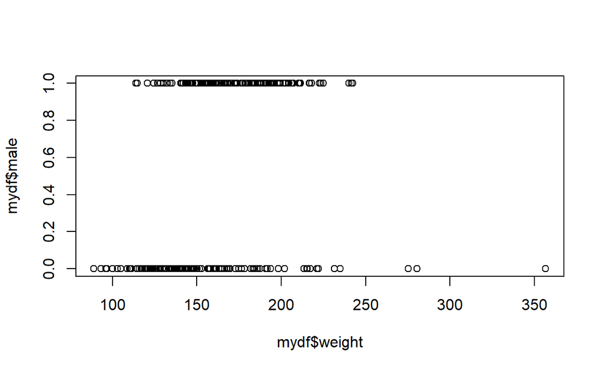

```r
plot(mydf$weight,mydf$male)
```

In the lower right corner there are some outliers representing heavy females.  
Such observations cause bias of model parameters.

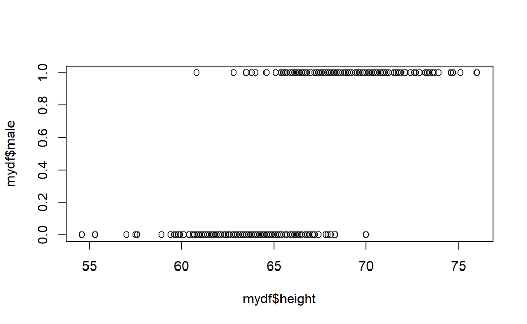

```r
plot(mydf$height,mydf$male)
```

On the plot relative to height outliers are short males.

What does a model robust to such outliers look like?

Robust logistic regression is a mix of “guessing model” and logistic model

$$\mu = \alpha \frac{1}{2} + (1 - \alpha)
\ \text{logistic}\Big(\beta_0 + \sum_j \beta_j x_j\Big)$$

- When $\alpha = 0$ all observations fit within logistic regression pattern, i.e. the classes are separated well enough to be explained by logistic sigmoid function. In this case the model becomes pure logistic regression.
- When $\alpha = 1$ the classes overlap completely and the model can only guess with probability 0.5 to which class the observation belongs.

Typically $\alpha$ is small (few outliers showing that predictor points to wrong class).  
Select beta distribution as a prior to $\alpha$ with high concentration near zero: dbeta(1,9).

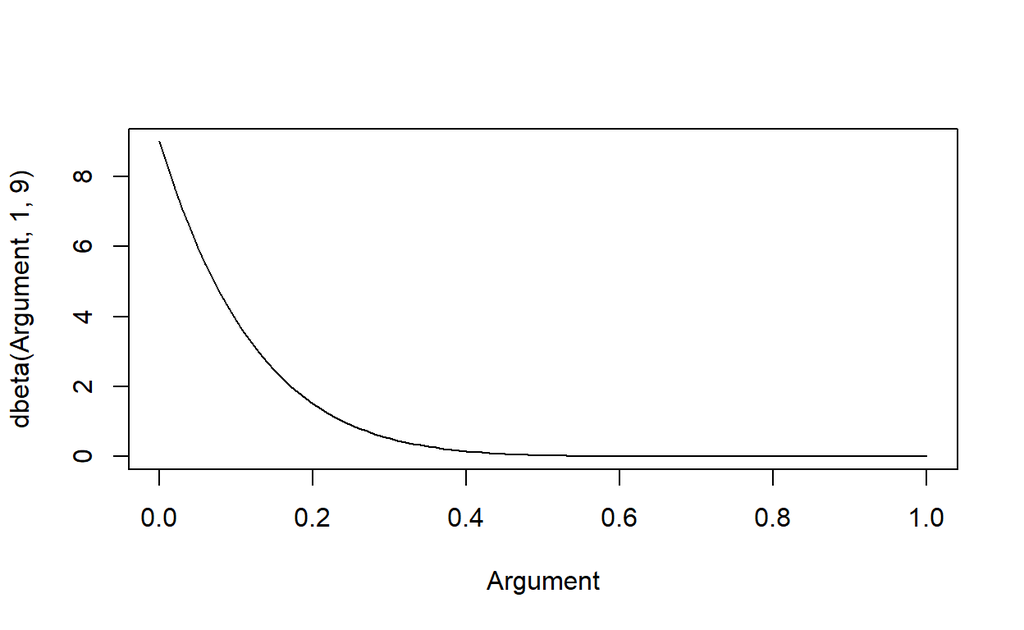

```r
Argument <- seq(from=0,to=1,by=.01)
plot(Argument, dbeta(Argument, 1, 9), type="l")
```

The modified model is on the

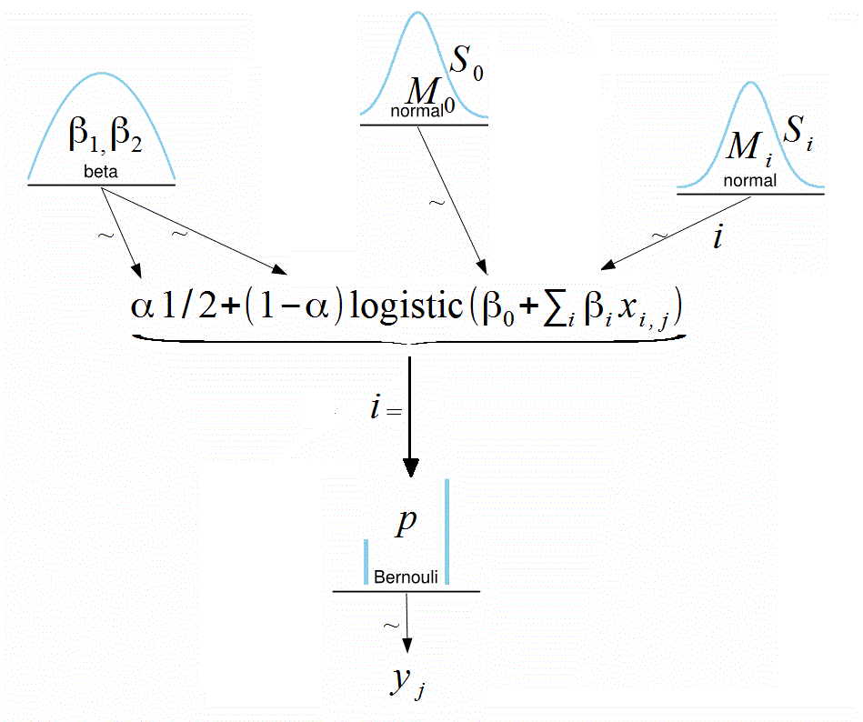

.

```r
modelString=
"data {                   // ROBUST LOGISTIC REGRESSION
    int<lower=1> Ntotal;  // num of observations
    int<lower=1> Nx;      // num of predictors
    int<lower=0, upper=1> y[Ntotal];
    matrix[Ntotal, Nx] x;
}
transformed data {
    vector[Nx] meanX;
    vector[Nx] sdX;
    matrix[Ntotal, Nx] zx;  // normalized

    for ( j in 1:Nx ) {
        meanX[j] = mean(x[,j]);
        sdX[j] = sd(x[,j]);
        for ( i in 1:Ntotal ) {
            zx[i,j] = ( x[i,j] - meanX[j] ) / sdX[j];
        }
    }
}
parameters {
    real zbeta0;
    vector[Nx] zbeta;
    real<lower=0,upper=1> guess;  // mixture param
}
transformed parameters{
    vector[Ntotal] mu;
    for ( i in 1:Ntotal ) {
        mu[i] = guess * (1/2.0) + (1-guess) * inv_logit(zbeta0 + zx[i,] * zbeta);
    }
}
model {
    zbeta0 ~ normal(0, 2);
    zbeta  ~ normal(0, 2);
    guess ~ beta(1, 9);
    y ~ bernoulli(mu);
}
generated quantities {
    // Transform to original scale:
    real beta0;
    vector[Nx] beta;
    // .* and ./ are element-wise product and division
    beta0 =  zbeta0 - sum( zbeta .* meanX ./ sdX );
    beta =  zbeta ./ sdX;
}
"
```

```r
stanDsoRobustLogistic <- stan_model(model_code=modelString)
```

```r
# save(stanDsoRobustLogistic, file = "data/stanRobustLogisticDso.Rds")
load("data/stanRobustLogisticDso.Rds")
```

Run robust MCMC with the hight/weight data.

```r
fitRobust <- sampling(stanDsoRobustLogistic,
                data=heightWeightDataList,
                pars=c('beta0', 'beta', 'guess'),
                iter=5000, chains = 2, cores = 2)
```

Analyze results.

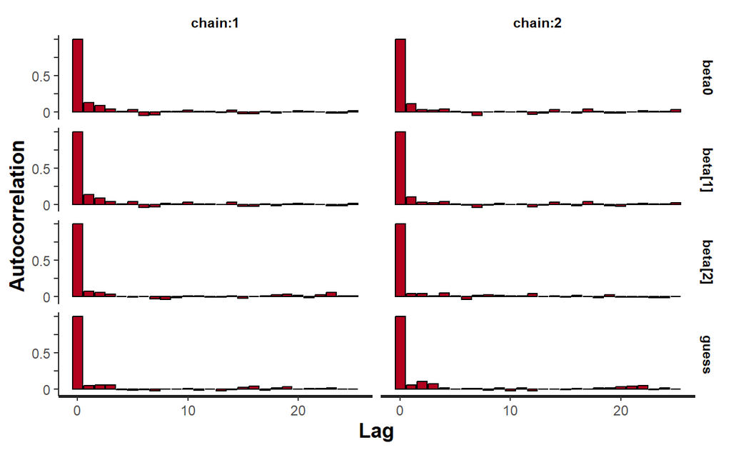

```r
stan_ac(fitRobust, separate_chains = T)
```

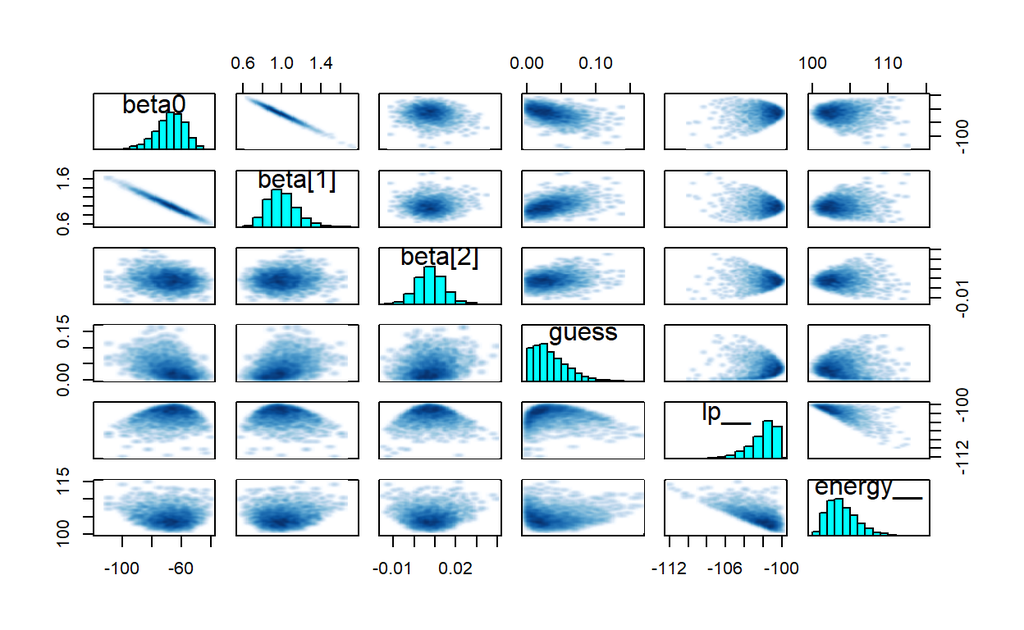

```r
pairs(fitRobust)
```

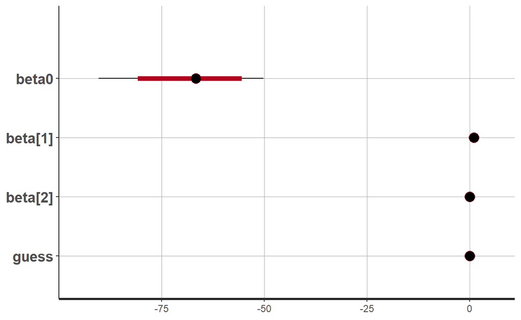

```r
plot(fitRobust)
```

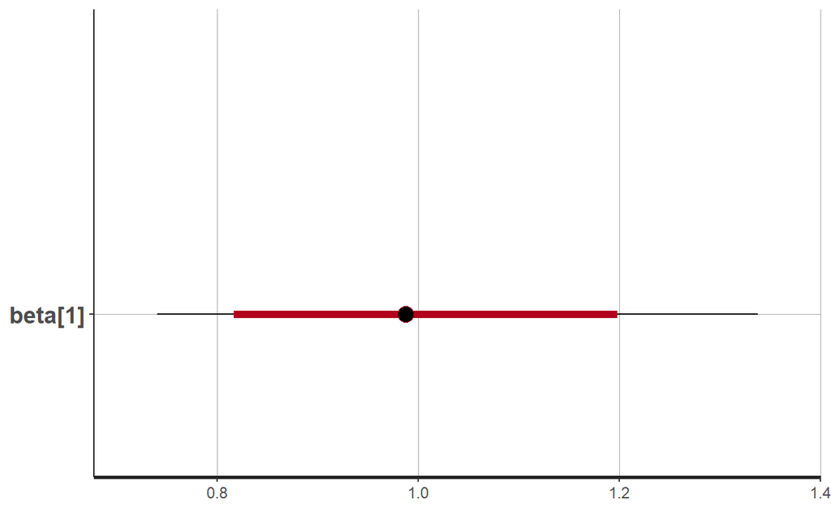

```r
plot(fitRobust,pars=c("beta[1]"))
```

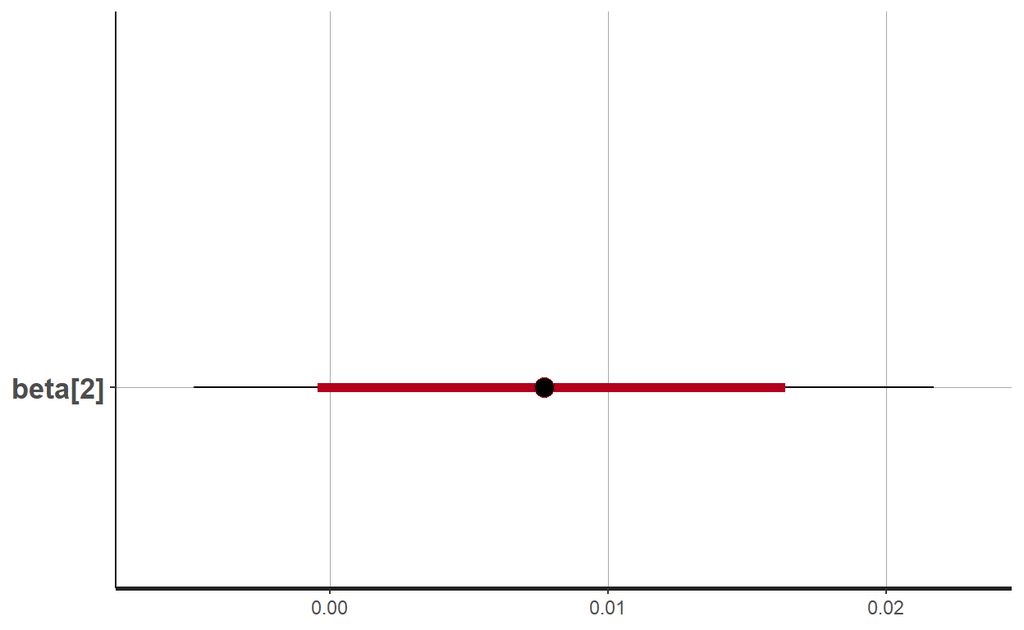

```r
plot(fitRobust,pars=c("beta[2]"))
```

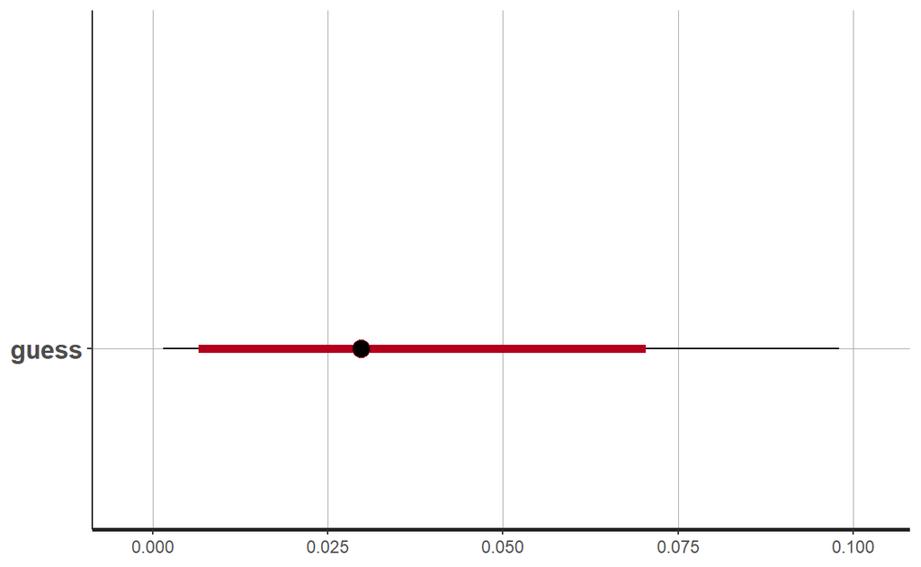

```r
plot(fitRobust,pars=c("guess"))
```

```r
rbind(summary(fitRobust)$summary[,c(1,4,7)],
      summary(fit)$summary[,c(1,4,8)]
)
```

```
                 mean          2.5%           75%
beta0   -6.759671e+01 -9.033603e+01  -60.44830982
beta[1]  9.987992e-01  7.405794e-01    1.08941932
beta[2]  7.863251e-03 -4.898361e-03    0.01200465
guess    3.520801e-02  1.562728e-03    0.04978482
lp__    -1.020473e+02 -1.058665e+02 -100.91970991
beta0   -5.907463e+01 -7.332501e+01  -46.74736282
beta[1]  8.761026e-01  6.866473e-01    1.08922356
beta[2]  5.720759e-03 -4.493517e-03    0.01585729
lp__    -9.768284e+01 -1.008467e+02  -96.28774967
```

Note positive correlation between guess and the slope $\beta_1$. The more outliers the higher is the slope.

Since $\beta_2$ does not seem significant. Now, we fit both models with height as only predictor.

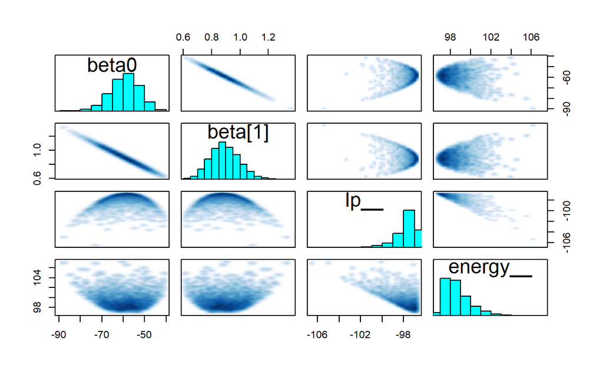

```r
heightWeightDataList<-list(Ntotal=nrow(mydf),
                          y=mydf$male,
                          x=cbind(mydf$height),
                          Nx=1)


fit <- sampling(stanDsoLogistic,
                data=heightWeightDataList,
                pars=c('beta0', 'beta'),
                iter=5000, chains = 2, cores = 2
)
fitRobust <- sampling(stanDsoRobustLogistic,
                data=heightWeightDataList,
                pars=c('beta0', 'beta', 'guess'),
                iter=5000, chains = 2, cores = 2
)
pairs(fit)
```

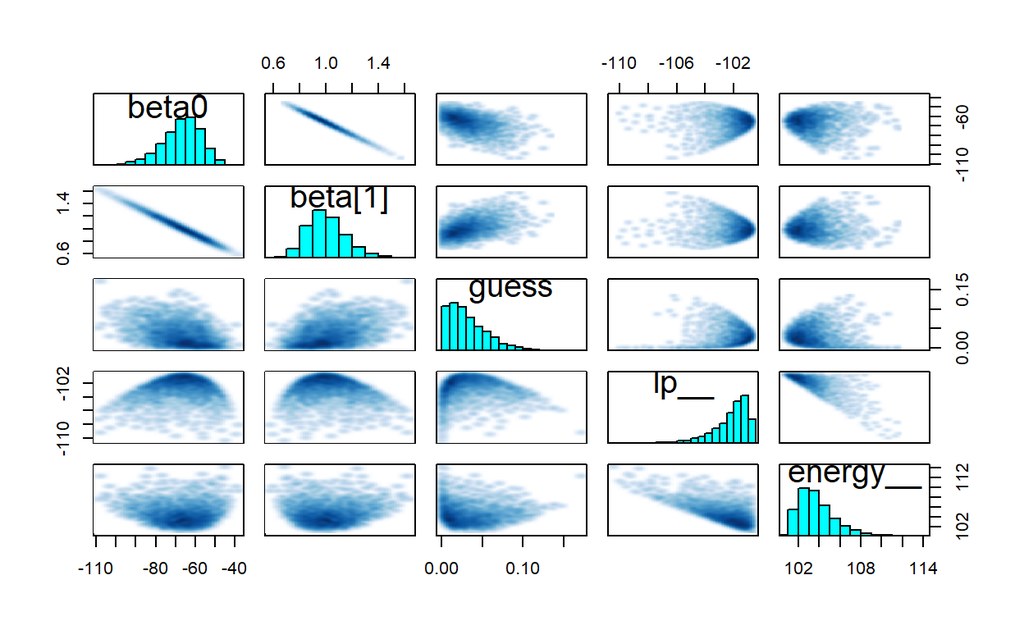

```r
pairs(fitRobust)
```

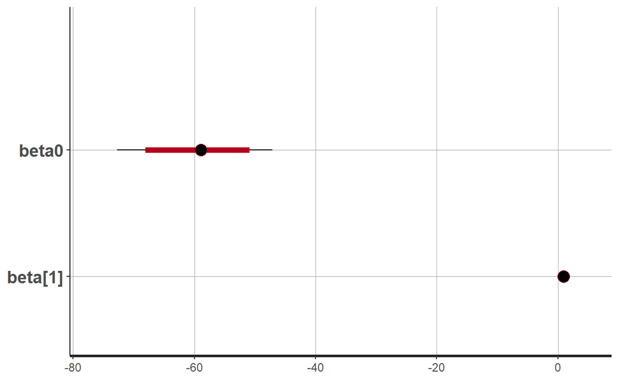

```r
plot(fit)
```

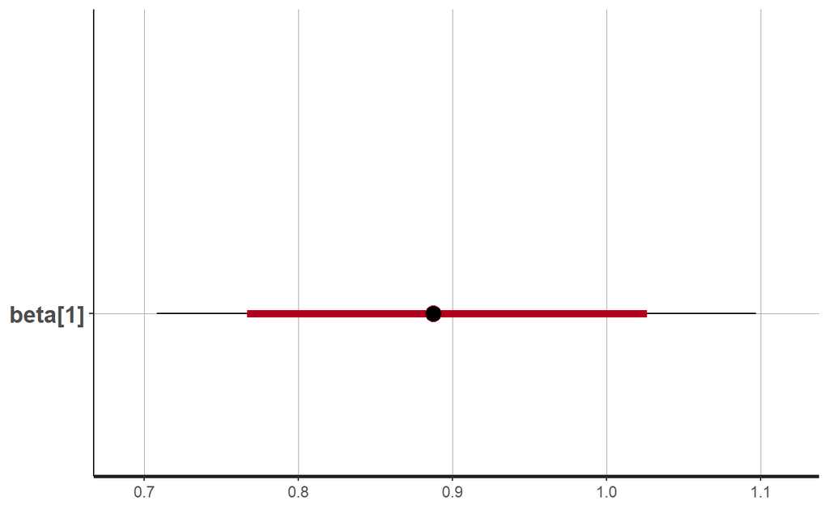

```r
plot(fit,pars=c("beta"))
```

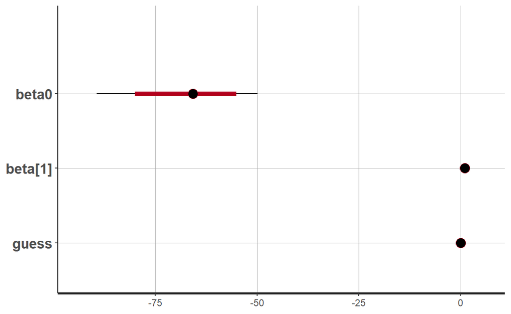

```r
plot(fitRobust)
```

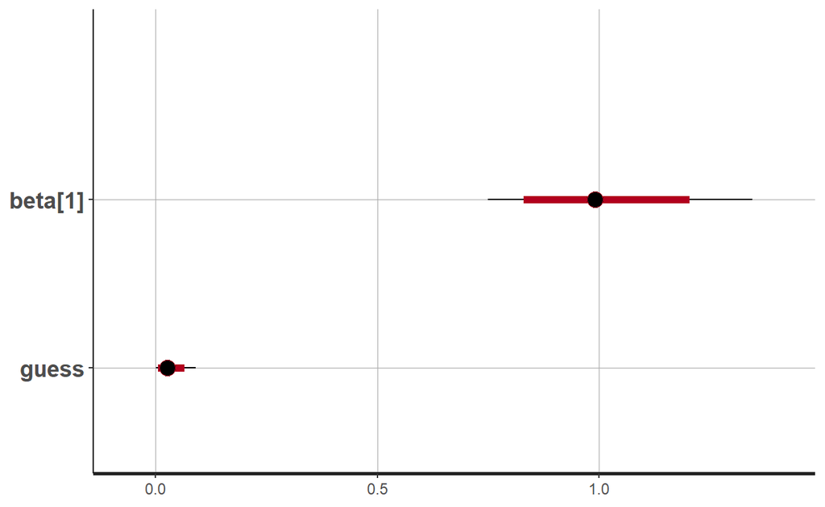

```r
plot(fitRobust,pars=c("beta[1]","guess"))
```

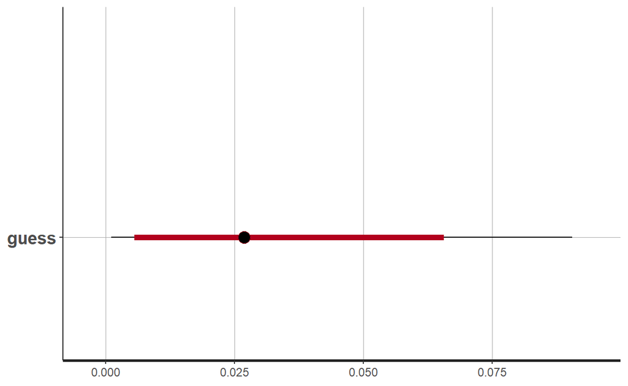

```r
plot(fitRobust,pars=c("guess"))
```

```r
rbind(summary(fitRobust)$summary[,c(1,4,7)],
      summary(fit)$summary[,c(1,4,8)]
)
```

```
                 mean          2.5%           75%
beta0    -66.86054035 -8.942821e+01  -59.89807734
beta[1]    1.00658061  7.500421e-01    1.09452331
guess      0.03199073  1.072547e-03    0.04549365
lp__    -102.27095400 -1.058139e+02 -101.30279477
beta0    -59.24314304 -7.275107e+01  -47.12218747
beta[1]    0.89230096  7.081439e-01    1.09712292
lp__     -97.71023494 -1.002870e+02  -96.75923890
```

Compare probabilities predicted by logistic regression and robust logistic regression.

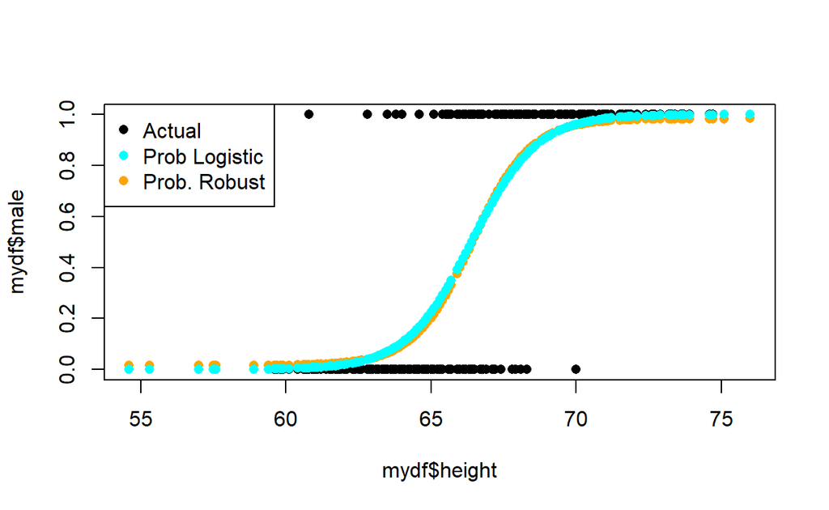

```r
# Coefficients
meanBeta0Robust<-summary(fitRobust)$summary[1,1]
meanBeta1Robust<-summary(fitRobust)$summary[2,1]
guess<-summary(fitRobust)$summary[3,1]
meanBeta0<-summary(fit)$summary[1,1]
meanBeta1<-summary(fit)$summary[2,1]

#Linear predictors and probabilities
linPredRobust_Male.Height<-meanBeta0Robust+meanBeta1Robust*mydf$height
pRobustMail_height<-guess/2+(1-guess)*exp(linPredRobust_Male.Height)/(1+exp(linPredRobust_Male.Height))
linPred_Male.Height<-meanBeta0+meanBeta1*mydf$height
pMail_height<-exp(linPred_Male.Height)/(1+exp(linPred_Male.Height))

# Plot
plot(mydf$height,mydf$male,pch=16)
points(mydf$height,pRobustMail_height,col="orange",pch=16)
points(mydf$height,pMail_height,col="cyan",pch=16)
legend("topleft",
       legend=c("Actual","Prob Logistic","Prob. Robust"),
       col=c("black","cyan","orange"), pch=16)
```

Logistic probability is more extreme: higher in the area of low-height male observations because it is biased by an outlier of short male below the average female height. But the far tails are closer to 0.  
Robust logistic regression did not react to this observation as much!!  
Robust model does not produce probabilities too close to 0 and 1.